# project2final

```python
%pip install pandas matplotlib seaborn
```

```python
import pandas as pd
import matplotlib.pyplot as plt
import seaborn as sns
```

```python
df = pd.read_csv("athlete_events.csv")
df.head()
```

|  | ID | Name | Sex | Age | Height | Weight | Team | NOC | Games | Year | Season | City | Sport | Event | Medal |
| --- | --- | --- | --- | --- | --- | --- | --- | --- | --- | --- | --- | --- | --- | --- | --- |
| 0 | 1 | A Dijiang | M | 24.0 | 180.0 | 80.0 | China | CHN | 1992 Summer | 1992 | Summer | Barcelona | Basketball | Basketball Men's Basketball | NaN |
| 1 | 2 | A Lamusi | M | 23.0 | 170.0 | 60.0 | China | CHN | 2012 Summer | 2012 | Summer | London | Judo | Judo Men's Extra-Lightweight | NaN |
| 2 | 3 | Gunnar Nielsen Aaby | M | 24.0 | NaN | NaN | Denmark | DEN | 1920 Summer | 1920 | Summer | Antwerpen | Football | Football Men's Football | NaN |
| 3 | 4 | Edgar Lindenau Aabye | M | 34.0 | NaN | NaN | Denmark/Sweden | DEN | 1900 Summer | 1900 | Summer | Paris | Tug-Of-War | Tug-Of-War Men's Tug-Of-War | Gold |
| 4 | 5 | Christine Jacoba Aaftink | F | 21.0 | 185.0 | 82.0 | Netherlands | NED | 1988 Winter | 1988 | Winter | Calgary | Speed Skating | Speed Skating Women's 500 metres | NaN |

```python
import pandas as pd
import numpy as np
import matplotlib.pyplot as plt
import seaborn as sns

pd.set_option('display.max_columns', None)
```

```python
df = pd.read_csv("athlete_events.csv")
df.head()
```

|  | ID | Name | Sex | Age | Height | Weight | Team | NOC | Games | Year | Season | City | Sport | Event | Medal |
| --- | --- | --- | --- | --- | --- | --- | --- | --- | --- | --- | --- | --- | --- | --- | --- |
| 0 | 1 | A Dijiang | M | 24.0 | 180.0 | 80.0 | China | CHN | 1992 Summer | 1992 | Summer | Barcelona | Basketball | Basketball Men's Basketball | NaN |
| 1 | 2 | A Lamusi | M | 23.0 | 170.0 | 60.0 | China | CHN | 2012 Summer | 2012 | Summer | London | Judo | Judo Men's Extra-Lightweight | NaN |
| 2 | 3 | Gunnar Nielsen Aaby | M | 24.0 | NaN | NaN | Denmark | DEN | 1920 Summer | 1920 | Summer | Antwerpen | Football | Football Men's Football | NaN |
| 3 | 4 | Edgar Lindenau Aabye | M | 34.0 | NaN | NaN | Denmark/Sweden | DEN | 1900 Summer | 1900 | Summer | Paris | Tug-Of-War | Tug-Of-War Men's Tug-Of-War | Gold |
| 4 | 5 | Christine Jacoba Aaftink | F | 21.0 | 185.0 | 82.0 | Netherlands | NED | 1988 Winter | 1988 | Winter | Calgary | Speed Skating | Speed Skating Women's 500 metres | NaN |

Olympic Athlete Data Analysis (1896–2016)

DS 220 — Project #2: Data Analysis with Python Akseli Karsikas

This project explores long-term trends in Olympic athlete demographics and performance using a publicly available dataset hosted on Zenodo, covering all modern Olympic Games from 1896 to 2016.

Motivation

The Olympic Games provide one of the most complete long-term datasets in sports history. With athlete records spanning more than 120 years, this dataset makes it possible to study how athlete characteristics, participation, and medal outcomes have evolved over time. As someone who competes in elite gymnastics with the dream of making the Olympics one day, I was especially interested in exploring how factors such as age, height, weight, and gender vary by sport and decade.

Understanding these trends helps reveal how different sports have changed, which countries dominate specific events, and how athlete demographics reflect larger social and historical shifts in global sport. This makes the Olympic dataset a rich and meaningful subject for data analysis using Python.

Dataset Provenance

The dataset used in this project is the Full Olympics Dataset (athlete_events.csv) hosted on Zenodo, a public open-access repository operated by CERN and OpenAIRE. Zenodo assigns each dataset a DOI to ensure long-term accessibility and reproducibility.

The dataset includes athlete-level records for every modern Olympic Games from 1896 to 2016, including characteristics such as age, sex, height, weight, sport, event, team, NOC (country code), and medal results.

I downloaded the dataset on December 10, 2025 from the following link:

Zenodo Record: https://zenodo.org/records/11449966

Direct CSV Download: https://zenodo.org/records/11449966/files/athlete_events.csv?download=1

Data Cleaning

Steps I took before statring the analysis

Removed duplicate entries

Removed rows with invalid entries

Created a boolean column to determine medalists

```python
#removing all the duplicates
df = df.drop_duplicates()

#removing invalid entreis or 0 that might skew the analysis
df = df[(df["Height"] > 0) & (df["Weight"] > 0)]

#medal indicator
df["Medalist"] = df["Medal"].notnull()

df.info()
```

```
<class 'pandas.core.frame.DataFrame'>
Index: 206840 entries, 0 to 271115
Data columns (total 16 columns):
 #   Column    Non-Null Count   Dtype
---  ------    --------------   -----
 0   ID        206840 non-null  int64
 1   Name      206840 non-null  object
 2   Sex       206840 non-null  object
 3   Age       206152 non-null  float64
 4   Height    206840 non-null  float64
 5   Weight    206840 non-null  float64
 6   Team      206840 non-null  object
 7   NOC       206840 non-null  object
 8   Games     206840 non-null  object
 9   Year      206840 non-null  int64
 10  Season    206840 non-null  object
 11  City      206840 non-null  object
 12  Sport     206840 non-null  object
 13  Event     206840 non-null  object
 14  Medal     30196 non-null   object
 15  Medalist  206840 non-null  bool
dtypes: bool(1), float64(3), int64(2), object(10)
memory usage: 25.4+ MB
```

Exploratory Data Analysis

Here I will be exploring the general patterns in the dataset, including summary statistics and distributions.

```python
df.describe()
```

|  | ID | Age | Height | Weight | Year |
| --- | --- | --- | --- | --- | --- |
| count | 206840.000000 | 206152.000000 | 206840.000000 | 206840.000000 | 206840.000000 |
| mean | 68582.371940 | 25.054736 | 175.359200 | 70.677359 | 1989.606643 |
| std | 39006.718284 | 5.481679 | 10.541733 | 14.330691 | 20.160306 |
| min | 1.000000 | 11.000000 | 127.000000 | 25.000000 | 1896.000000 |
| 25% | 35139.000000 | 21.000000 | 168.000000 | 60.000000 | 1976.000000 |
| 50% | 68595.000000 | 24.000000 | 175.000000 | 70.000000 | 1992.000000 |
| 75% | 102283.000000 | 28.000000 | 183.000000 | 79.000000 | 2006.000000 |
| max | 135571.000000 | 71.000000 | 226.000000 | 214.000000 | 2016.000000 |

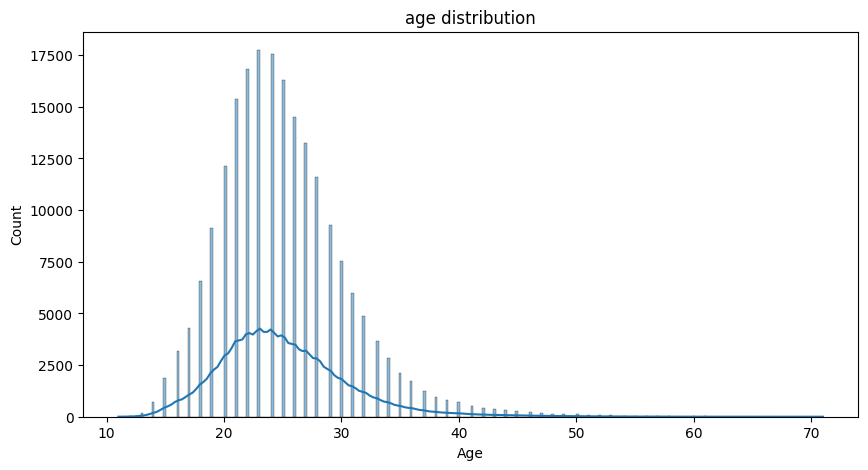

```python
plt.figure(figsize=(10,5))
sns.histplot(df["Age"], kde=True)
plt.title("age distribution")
plt.show()
```

# Research section

Q1: How has the average age of olympians changed over time? Important question since I'm a gymnast and there has been a lot of talks about wheter coaches are making athletes peak too young.

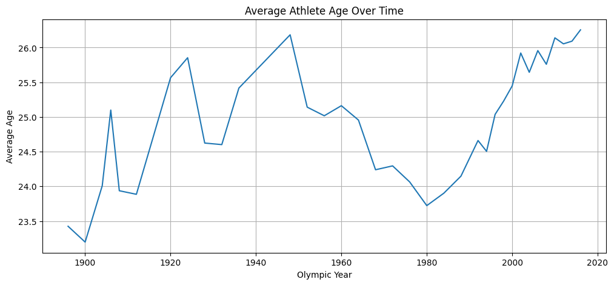

```python
age_by_year = df.groupby("Year")["Age"].mean()

plt.figure(figsize=(12,5))
plt.plot(age_by_year.index, age_by_year.values)
plt.title("Average Athlete Age Over Time")
plt.xlabel("Olympic Year")
plt.ylabel("Average Age")
plt.grid(True)
plt.show()
```

Q2: Which sports have the shortest athletes? I assume I'll see gymnastics here.

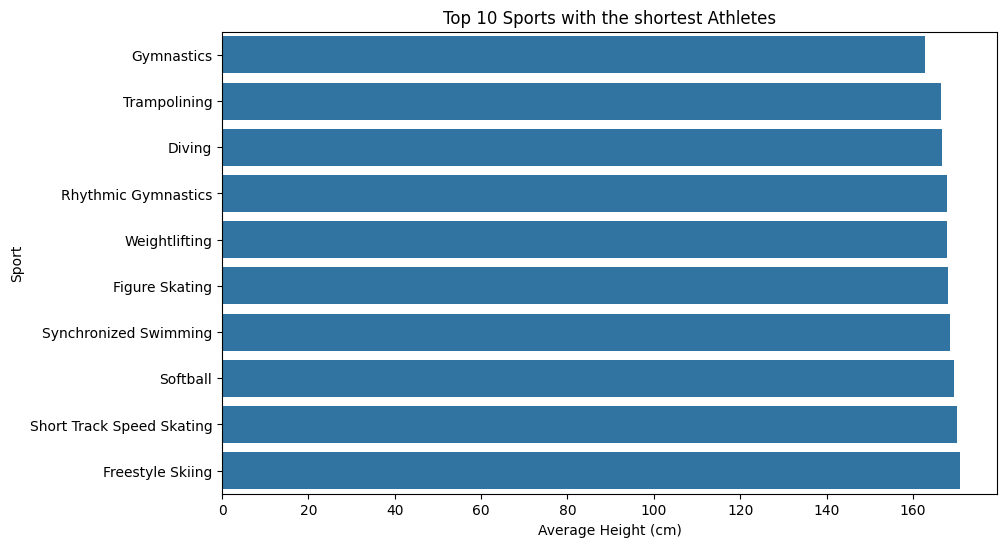

```python
shortest = df.groupby("Sport")["Height"].mean().sort_values(ascending=True).head(10)

plt.figure(figsize=(10,6))
sns.barplot(x=shortest.values, y=shortest.index)
plt.title("Top 10 Sports with the shortest Athletes")
plt.xlabel("Average Height (cm)")
plt.show()
```

Q3: Which countries have the most medals? I'm hoping to see Finland making the cut, since it's my home country.

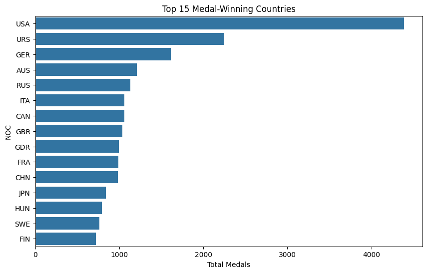

```python
medals = df[df["Medalist"]].groupby("NOC")["Medalist"].count().sort_values(ascending=False).head(15)

plt.figure(figsize=(10,6))
sns.barplot(x=medals.values, y=medals.index)
plt.title("Top 15 Medal-Winning Countries")
plt.xlabel("Total Medals")
plt.show()
```

Q4: Which countries have the least medals. I think I'll see some interesting countries here. (countries that have atleast 1 medal)

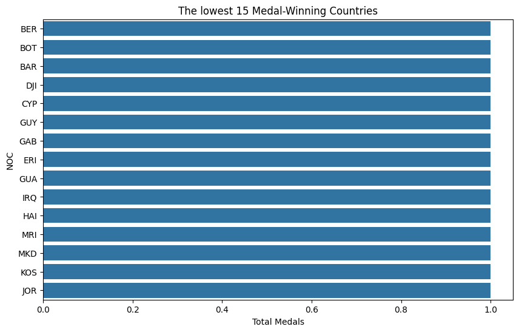

```python
medals = df[df["Medalist"]].groupby("NOC")["Medalist"].count().sort_values(ascending=True).head(15)

plt.figure(figsize=(10,6))
sns.barplot(x=medals.values, y=medals.index)
plt.title("The lowest 15 Medal-Winning Countries")
plt.xlabel("Total Medals")
plt.show()
```

Q5: How do Gymnastics athletes compare in height and weight?

```python
gym = df[df["Sport"]=="Gymnastics"]
others = df[df["Sport"]!="Gymnastics"]

stats = pd.DataFrame({
    "Gymnastics Height Mean": [gym["Height"].mean()],
    "Other Sports Height Mean": [others["Height"].mean()],
    "Gymnastics Weight Mean": [gym["Weight"].mean()],
    "Other Sports Weight Mean": [others["Weight"].mean()],
})

stats
```

|  | Gymnastics Height Mean | Other Sports Height Mean | Gymnastics Weight Mean | Other Sports Weight Mean |
| --- | --- | --- | --- | --- |
| 0 | 162.875641 | 176.572764 | 56.913675 | 72.015368 |

Q6: What ages are most common among medalists vs non-medalists?

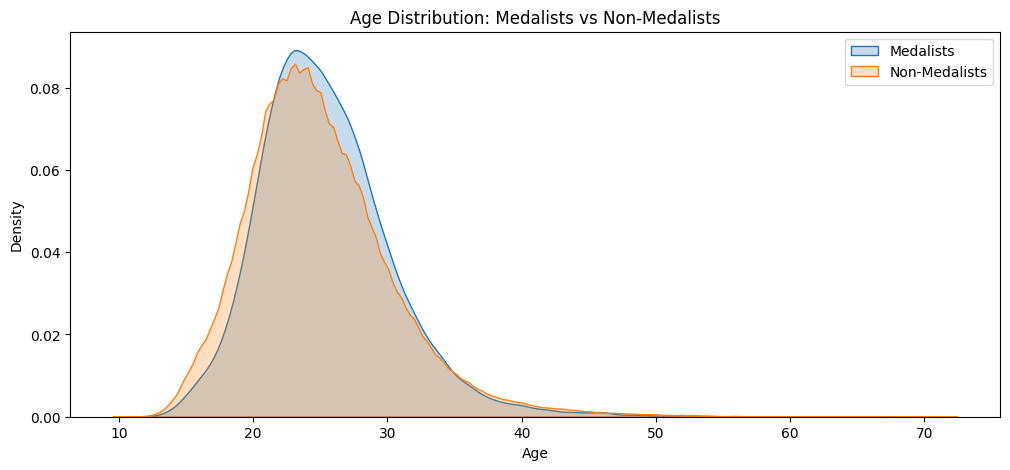

```python
plt.figure(figsize=(12,5))
sns.kdeplot(df[df["Medalist"]]["Age"], label="Medalists", fill=True)
sns.kdeplot(df[~df["Medalist"]]["Age"], label="Non-Medalists", fill=True)
plt.title("Age Distribution: Medalists vs Non-Medalists")
plt.xlabel("Age")
plt.legend()
plt.show()
```

Final Insights

This project revealed several long-term trends in Olympic athlete demographics and performance. Athlete age, body size, and medal distribution show meaningful patterns across more than a century of Olympic history. Height and weight vary dramatically by sport, and Gymnastics in particular has distinctly smaller athletes. Countries with established sports infrastructure (USA, Russia, Germany) dominate the medal tables. Though developed smaller countries like Finland can rack up pretty impressing numbers of medals despite their small population.